# Lab 5

## Part 1: Data Exploration

### 1: Data display and summary

```python
import pandas as pd
import numpy as np
```

```python
insurance = pd.read_csv("~/Desktop/GSB 544/Labs/Lab_5/insurance_costs_1.csv", sep=',')
```

```python
insurance.head()
```

|  | age | sex | bmi | smoker | region | charges |
| --- | --- | --- | --- | --- | --- | --- |
| 0 | 19 | female | 27.900 | yes | southwest | 16884.92400 |
| 1 | 33 | male | 22.705 | no | northwest | 21984.47061 |
| 2 | 32 | male | 28.880 | no | northwest | 3866.85520 |
| 3 | 31 | female | 25.740 | no | southeast | 3756.62160 |
| 4 | 60 | female | 25.840 | no | northwest | 28923.13692 |

```python
insurance.info()
```

```
<class 'pandas.core.frame.DataFrame'>
RangeIndex: 431 entries, 0 to 430
Data columns (total 6 columns):
 #   Column   Non-Null Count  Dtype
---  ------   --------------  -----
 0   age      431 non-null    int64
 1   sex      431 non-null    object
 2   bmi      431 non-null    float64
 3   smoker   431 non-null    object
 4   region   431 non-null    object
 5   charges  431 non-null    float64
dtypes: float64(2), int64(1), object(3)
memory usage: 20.3+ KB
```

### 2: Data cleaning

```python
insurance=insurance.dropna()
```

### 3: Plots to visualize data

```python
import plotnine as p9
```

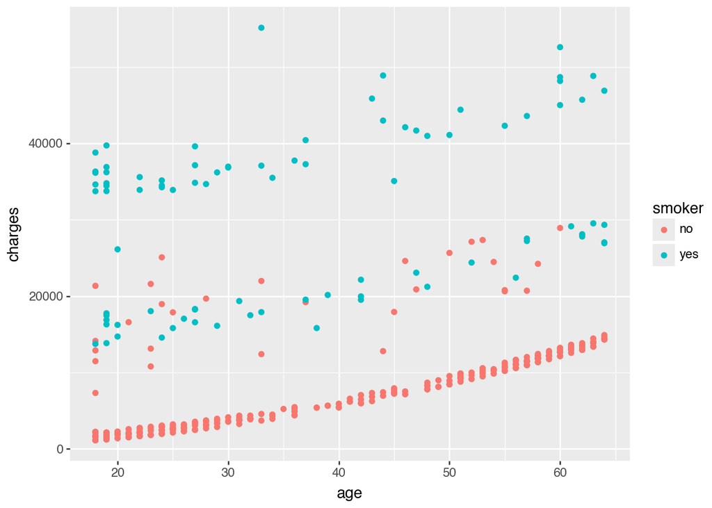

```python
(p9.ggplot(insurance,
p9.aes(
  x = "age",
  y = "charges",
  color = "smoker"
))
+ p9.geom_point()
)
```

This plot suggests that as age increases, insurance charges additionally increase. It also suggests the existence of three distinct y intercepts/groups within the data, the first being smokers with high charges, the second being a mix of smokers and non smokers with medium charges, and the last is non smokers with low charges. We will investigate other variables to see what may further define these groups.

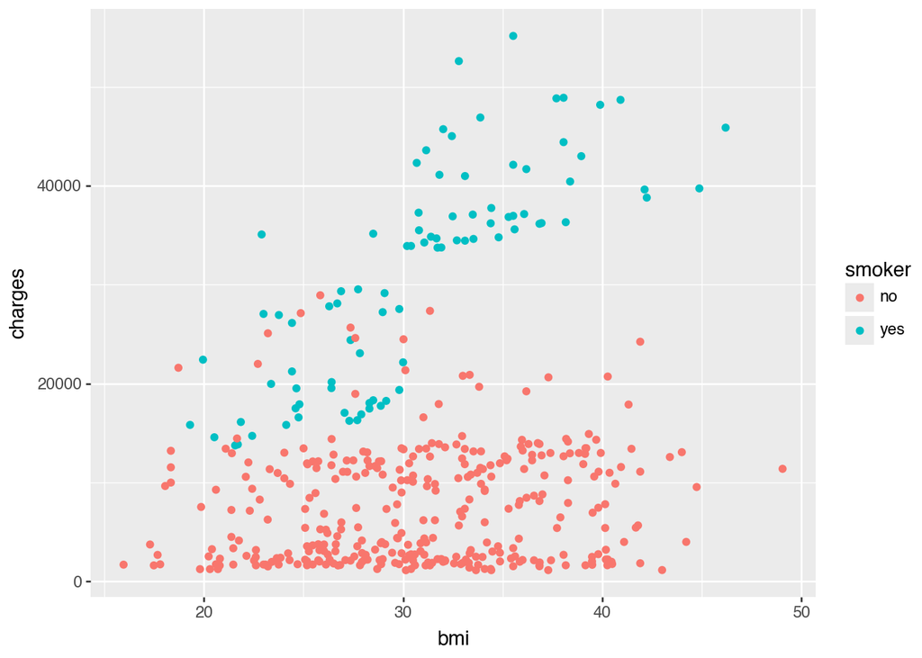

```python
(p9.ggplot(insurance,
p9.aes(
  x = "bmi",
  y = "charges",
  color = "smoker"
))
+ p9.geom_point()
)
```

BMI does not appear to have a signfiicant linear relationship to insurance charges for non-smokers, but it appears to have a linear relationship to charges for smokers. The scatterplot suggests that a higher BMI corresponds to higher insurance charges for smokers.

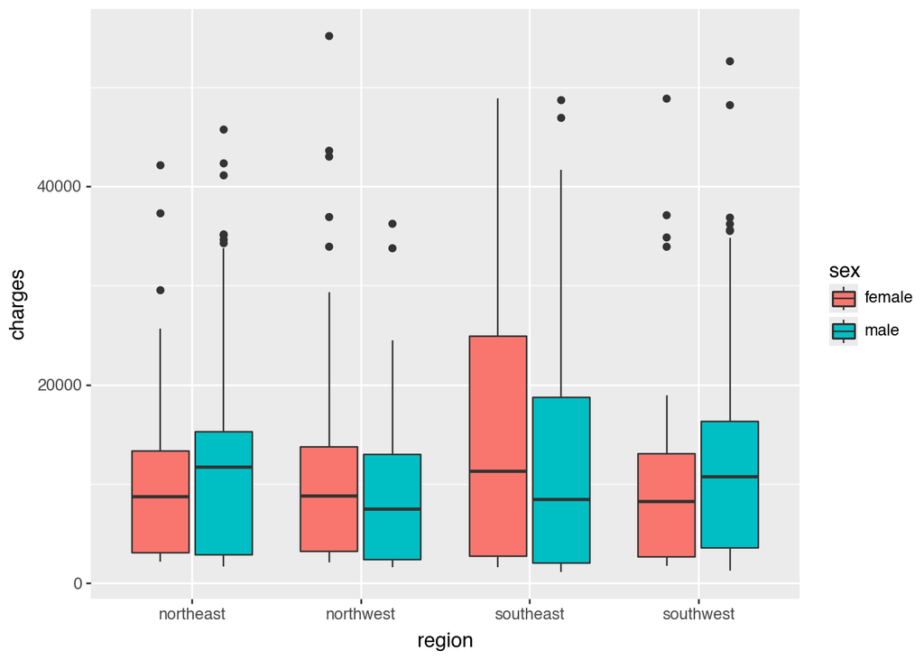

```python
(p9.ggplot(insurance,
p9.aes(
  x = "region",
  y = "charges",
  fill="sex"
))
+ p9.geom_boxplot()
)
```

## Part 2: Simple Linear Models

### 1: A simple linear model to predict the insurance charges from the beneficiary’s age

```python
from sklearn.linear_model import LinearRegression
from sklearn.metrics import r2_score
```

```python
lr = LinearRegression()
```

```python
y=insurance['charges']
X=insurance[['age']]
```

```python
lr_fit = lr.fit(X, y)
lr_coef=lr_fit.coef_
lr_int=lr_fit.intercept_
lr_coef, lr_int
```

```
(array([228.79904937]), np.float64(3611.758798507106))
```

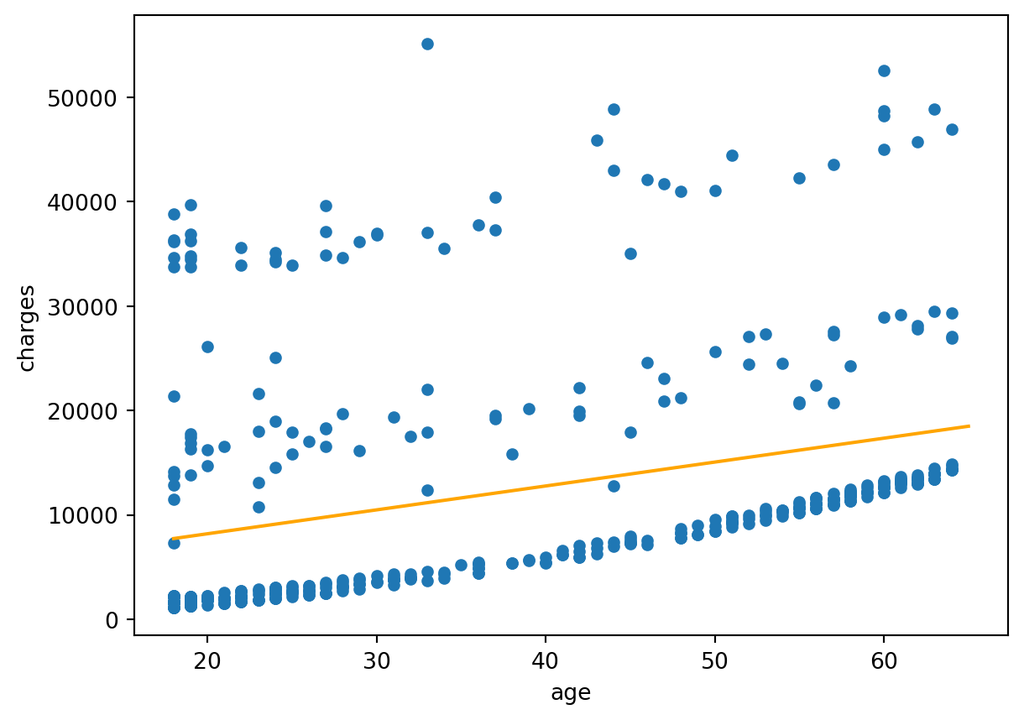

```python
X_new = pd.DataFrame()
X_new["age"] = np.linspace(18, 65, num=10000)
y_new_ = pd.Series(
    lr_fit.predict(X_new),
    index=X_new["age"]
)

insurance.plot.scatter(x="age", y="charges")
y_new_.plot.line(c = "orange");
```

```python
from sklearn.metrics import mean_squared_error, root_mean_squared_error, mean_absolute_error, r2_score

mean_squared_error(insurance['charges'], lr_fit.predict(X)), r2_score(insurance['charges'], lr_fit.predict(X))
```

```
(126739267.91026388, 0.09938105452062707)
```

The average squared distance from points to the regression line is 126739267.91026388.

The R^2 value of this model is 0.09938. This means that 9.938% of total variablilty in insurance charges can be explained by its linear relationship to age. Thus, age alone does not describe a significant amount of variability in insurance charges.

### 2: Expanding the model to also include the variable sex

```python
from sklearn.preprocessing import OneHotEncoder
enc=OneHotEncoder(handle_unknown='ignore')

malefemale=enc.fit(insurance[['sex']])
malefemale=malefemale.transform(insurance[['sex']]).todense()
insurance["is_female"]=pd.DataFrame(malefemale)[0]

smokes=enc.fit(insurance[['smoker']])
smokes=smokes.transform(insurance[['smoker']]).todense()
insurance["is_smoker"]=pd.DataFrame(smokes)[1]
```

```python
X2=insurance[['age', 'is_female']]
X3=insurance[['age', 'is_smoker']]
```

```python
lr_female = LinearRegression()
lr_female.fit(X2, y)
lr_female_coef=lr_female.coef_
lr_female_int=lr_female.intercept_
lr_female_coef, lr_female_int
```

```
(array([ 228.42586236, -649.83258997]), np.float64(3965.1649365068024))
```

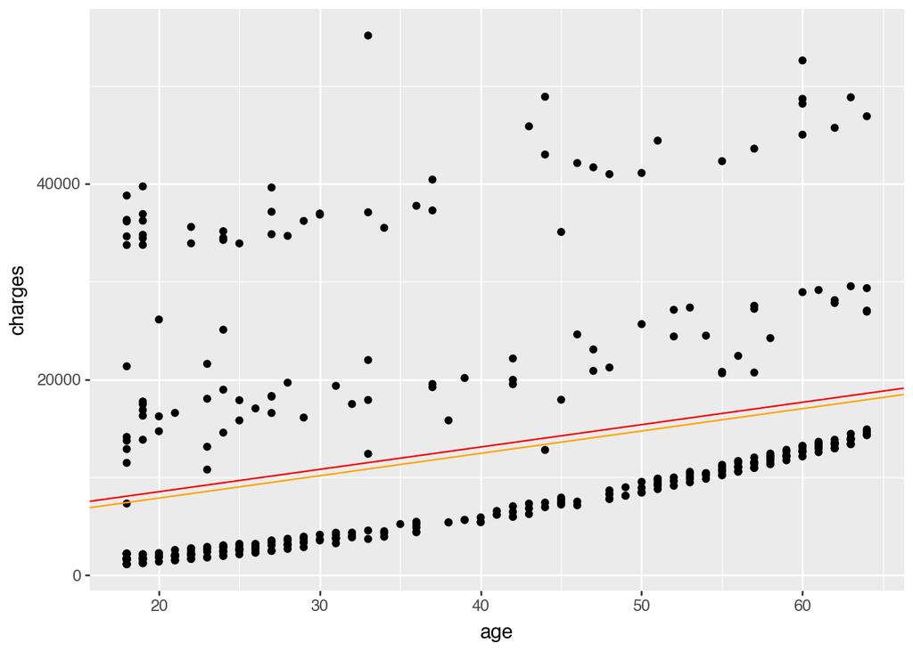

```python
(p9.ggplot(insurance,
p9.aes(
  x = "age",
  y = "charges"
))
+ p9.geom_point()
+ p9.geom_abline(intercept=3965.1649365068024, slope=228.42586236, color='red')
+ p9.geom_abline(intercept=3965.1649365068024-649.83258997, slope=228.42586236, color='orange')
)
```

On average, we expect females to have lower charges than males by $649.83, while holding age constant.

### 3: Exploring a model that uses smoking status instead of sex

```python
lr_smoke = LinearRegression()
lr_smoke.fit(X3, y)
lr_smoke_coef=lr_smoke.coef_
lr_smoke_int=lr_smoke.intercept_
lr_smoke_coef, lr_smoke_int
```

```
(array([  253.14535549, 24048.86743795]), np.float64(-2166.852295375431))
```

On average, we expect smokers to have higher charges than non-smokers by 24048.86743795, while holding age constant.

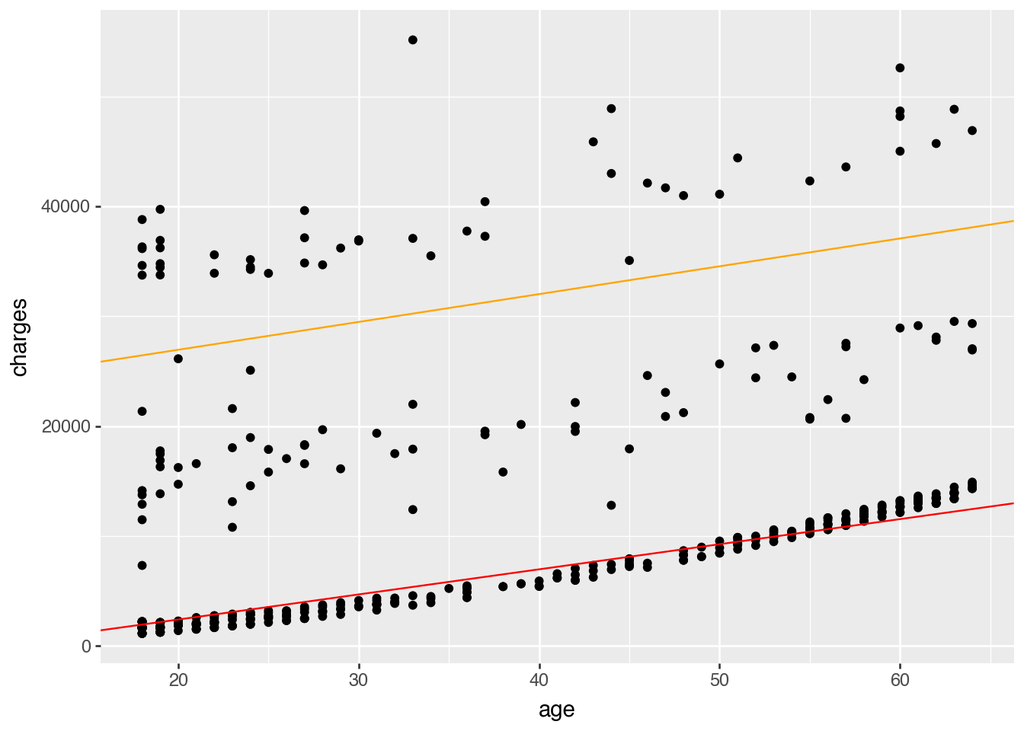

```python
(p9.ggplot(insurance,
p9.aes(
  x = "age",
  y = "charges"
))
+ p9.geom_point()
+ p9.geom_abline(intercept=-2166.852295375431, slope=228.42586236, color='red')
+ p9.geom_abline(intercept=-2166.852295375431+24048.86743795, slope=253.14535549, color='orange')
)
```

### 4: Comparing models with age and sex vs age and smoking

Comparing the MSE values of the models:

```python
mean_squared_error(insurance["charges"], lr_female.predict(X2))
```

```
126633939.67937087
```

```python
r2_score(insurance['charges'], lr_female.predict(X2))
```

```
0.10012952499706396
```

The MSE of the model containing sex is 126633939.67937087, and the R^2 of this model is 0.10012952499706396.

```python
mean_squared_error(insurance['charges'], lr_smoke.predict(X3))
```

```
33719831.46524373
```

```python
r2_score(insurance['charges'], lr_smoke.predict(X3))
```

```
0.7603842948069404
```

## Part 3: Multiple Linear Models

### 1: Fitting a model using age and BMI as predictors (no interaction term)

```python
lr_age_bmi=LinearRegression()
X4=insurance[['age', 'bmi']]
lr_age_bmi.fit(X4, y)
lr_age_bmi_coef=lr_age_bmi.coef_
lr_age_bmi_int=lr_age_bmi.intercept_
lr_age_bmi_coef, lr_age_bmi_int
```

```
(array([216.29721472, 283.20380126]), np.float64(-4627.533445708479))
```

```python
mean_squared_error(insurance["charges"], lr_age_bmi.predict(X4))
```

```
123792439.58129103
```

```python
r2_score(insurance['charges'], lr_age_bmi.predict(X4))
```

```
0.12032144234129338
```

### 2: Fitting a model that uses age and age^2

```python
X_deg=insurance[['age']]
X_deg['age_squared']=X_deg['age'] ** 2
```

```python
lr_age_sq=LinearRegression()
lr_age_sq.fit(X_deg, y)
lr_age_sq_coef=lr_age_sq.coef_
lr_age_sq_int=lr_age_sq.intercept_
lr_age_sq_coef, lr_age_sq_int
```

```
(array([308.42816984,  -1.00150889]), np.float64(2299.730568726698))
```

```python
mean_squared_error(insurance["charges"], lr_age_sq.predict(X_deg))
```

```
126710293.80956802
```

```python
r2_score(insurance['charges'], lr_age_sq.predict(X_deg))
```

```
0.09958694669946933
```

### 3: Fitting a polynomial model of degree 4

```python
X_deg['age_cubed']=X_deg['age']**3
X_deg['age_4']=X_deg['age']**4
```

```python
lr_age_4=LinearRegression()
lr_age_4.fit(X_deg, y)
lr_age_4_coef=lr_age_4.coef_
lr_age_4_int=lr_age_4.intercept_
lr_age_4_coef, lr_age_4_int
```

```
(array([-7.94841022e+03,  3.58110163e+02, -6.47905090e+00,  4.12933982e-02]),
 np.float64(68637.8978324551))
```

```python
mean_squared_error(insurance["charges"], lr_age_4.predict(X_deg))
```

```
125550389.64569846
```

```python
r2_score(insurance['charges'], lr_age_4.predict(X_deg))
```

```
0.10782931453183653
```

### 4: Fitting a polynomial model of degree 12

```python
X_deg['age_5']=X_deg['age']**5
X_deg['age_6']=X_deg['age']**6
X_deg['age_7']=X_deg['age']**7
X_deg['age_8']=X_deg['age']**8
X_deg['age_9']=X_deg['age']**9
X_deg['age_10']=X_deg['age']**10
X_deg['age_11']=X_deg['age']**11
X_deg['age_12']=X_deg['age']**12
```

```python
lr_age_12=LinearRegression()
lr_age_12.fit(X_deg, y)
lr_age_12_coef=lr_age_12.coef_
lr_age_12_int=lr_age_12.intercept_
lr_age_12_coef, lr_age_12_int
```

```
(array([ 3.04916765e-12,  1.74978335e-10,  3.30545342e-09,  7.57055097e-08,
         1.26243811e-06,  1.25112250e-05, -2.08395220e-08, -1.85914392e-08,
         4.09818497e-10, -2.52044358e-12, -1.01992093e-17,  1.42766017e-16]),
 np.float64(7452.282368586263))
```

```python
mean_squared_error(insurance["charges"], lr_age_12.predict(X_deg))
```

```
125373053.69364348
```

```python
r2_score(insurance['charges'], lr_age_12.predict(X_deg))
```

```
0.10908947739034713
```

### 5:

I would suggest that the model containing age and bmi is the best model in this part of the exploration. The R^2 and MSE values for these models back up my assumption as this model has the most optimal values. Additionally, the MSE and R^2 values did not get much better as more polynomial terms were added which suggests that is not what will improve the model.

### 6:

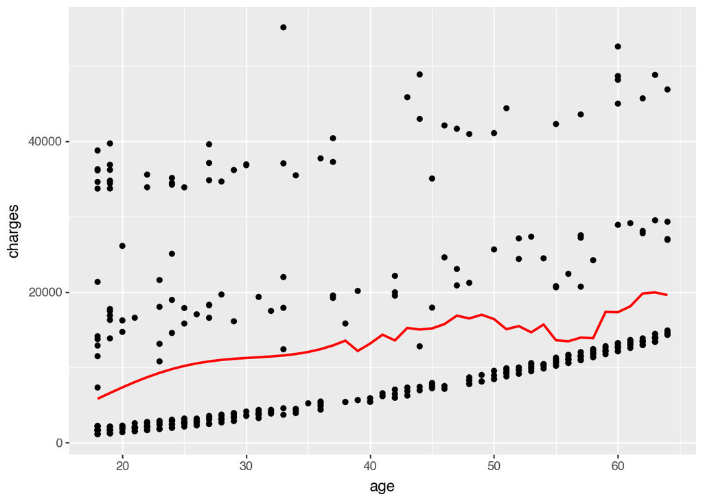

```python
import plotnine as p9

(p9.ggplot(insurance,
p9.aes(
  x = "age",
  y = "charges"
))
+ p9.geom_point()
+ p9.geom_smooth(method='lm', formula='y ~ x + I(x**2)+ I(x**3) + I(x**4) + I(x**5)+ I(x**6) + I(x**7)+ I(x**8)+ I(x**9) + I(x**10) + I(x**11)+ I(x**12)', se=False, color="red")
)
```

## Part 4: New Data

```python
insurance_new = pd.read_csv("https://www.dropbox.com/s/sky86agc4s8c6qe/insurance_costs_2.csv?dl=1", sep=',')
```

### Only age as a predictor

```python
r2_score(insurance_new['charges'], lr_fit.predict(insurance_new[['age']]))
```

```
0.12236515675533055
```

```python
mean_squared_error(insurance_new["charges"], lr_fit.predict(insurance_new[['age']]))
```

```
136077136.50195494
```

### Age and BMI as predictors

```python
r2_score(insurance_new['charges'], lr_age_bmi.predict(insurance_new[['age', 'bmi']]))
```

```
0.14455628272331222
```

```python
mean_squared_error(insurance_new['charges'], lr_age_bmi.predict(insurance_new[['age', 'bmi']]))
```

```
132636406.1108129
```

### Age, BMI, and smoking status as predictors

```python
enc_new=OneHotEncoder(handle_unknown='ignore')
smokes=enc_new.fit(insurance_new[['smoker']])
smokes=smokes.transform(insurance_new[['smoker']]).todense()
insurance_new["is_smoker"]=pd.DataFrame(smokes)[1]
```

```python
lr_age_bmi_smoker=LinearRegression()
X_age_bmi_smoker=insurance[['age', 'bmi', 'is_smoker']]
lr_age_bmi_smoker.fit(X_age_bmi_smoker, y)
```

```
LinearRegression()
```

```python
r2_score(insurance_new['charges'], lr_age_bmi_smoker.predict(insurance_new[['age', 'bmi', 'is_smoker']]))
```

```
0.7718311565047801
```

```python
mean_squared_error(insurance_new['charges'], lr_age_bmi_smoker.predict(insurance_new[['age', 'bmi', 'is_smoker']]))
```

```
35377541.24141632
```

### age, and bmi, with both quantitative variables having an interaction term with smoker (i.e. the formula ~ (age + bmi):smoker)

```python
insurance['smoke_age']=insurance['is_smoker']*insurance['age']
insurance['smoke_bmi']=insurance['is_smoker']*insurance['bmi']

insurance_new['smoke_age']=insurance_new["is_smoker"]*insurance_new['age']
insurance_new['smoke_bmi']=insurance_new["is_smoker"]*insurance_new['bmi']
```

```python
lr_smoke_int=LinearRegression()
X_smoke_int=insurance[['age', 'bmi', 'smoke_age', "smoke_bmi"]]
lr_smoke_int.fit(X_smoke_int, y)
```

```
LinearRegression()
```

```python
r2_score(insurance_new['charges'], lr_smoke_int.predict(insurance_new[['age', 'bmi', 'smoke_age', 'smoke_bmi']]))
```

```
0.8400778135676982
```

```python
mean_squared_error(insurance_new['charges'], lr_smoke_int.predict(insurance_new[['age', 'bmi', 'smoke_age', 'smoke_bmi']]))
```

```
24795908.41264334
```

### age, bmi, and smoker as predictors, with both quantitative variables having an interaction term with smoker (i.e. the formula ~ (age + bmi)*smoker)

```python
lr_all=LinearRegression()
X_all=insurance[['age', 'bmi', 'is_smoker', 'smoke_age', "smoke_bmi"]]
lr_all.fit(X_all, y)
lr_all.coef_, lr_all.intercept_
```

```
(array([ 2.58179772e+02,  5.36117114e+00, -2.09937051e+04, -1.24532947e+01,
         1.48116585e+03]),
 np.float64(-2524.685690084003))
```

```python
r2_score(insurance_new['charges'], lr_all.predict(insurance_new[['age', 'bmi', 'is_smoker', 'smoke_age', 'smoke_bmi']]))
```

```
0.859488679569962
```

```python
mean_squared_error(insurance_new['charges'], lr_all.predict(insurance_new[['age', 'bmi', 'is_smoker', 'smoke_age', 'smoke_bmi']]))
```

```
21786256.86685252
```

Based on these results, the last model is the best model to use due to how it has the highest R^2 value and the lowest MSE on the new data. However, the second to last model (model only containing age, bmi, and their interaction terms with smoker) can also be argued due to how it has similar MSE and R^2 values to the last model but it is simpler (contains less variables).

```python
insurance_new["is_smoker"]=insurance_new["is_smoker"].astype(int)
insurance_new["is_smoker"]=insurance_new["is_smoker"].astype(str)
```

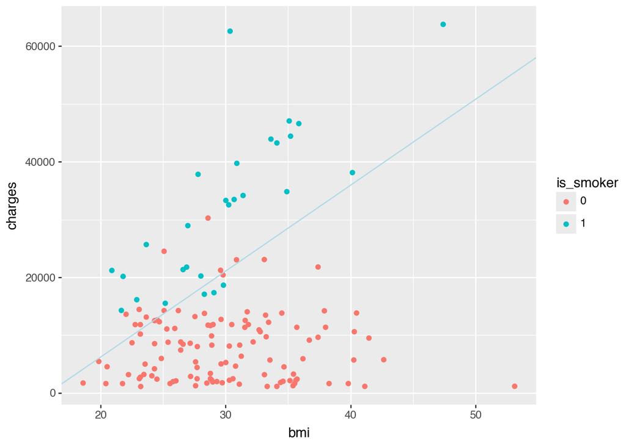

```python
(p9.ggplot(insurance_new,
p9.aes(
  x = "bmi",
  y = "charges",
  color="is_smoker"
))
+ p9.geom_point()
+ p9.geom_abline(intercept=-2524.69, slope=5.36117114, color='red')
+ p9.geom_abline(intercept=-2524.69-20993.71, slope=1481.16585+5.36117114, color='lightblue')
)
```

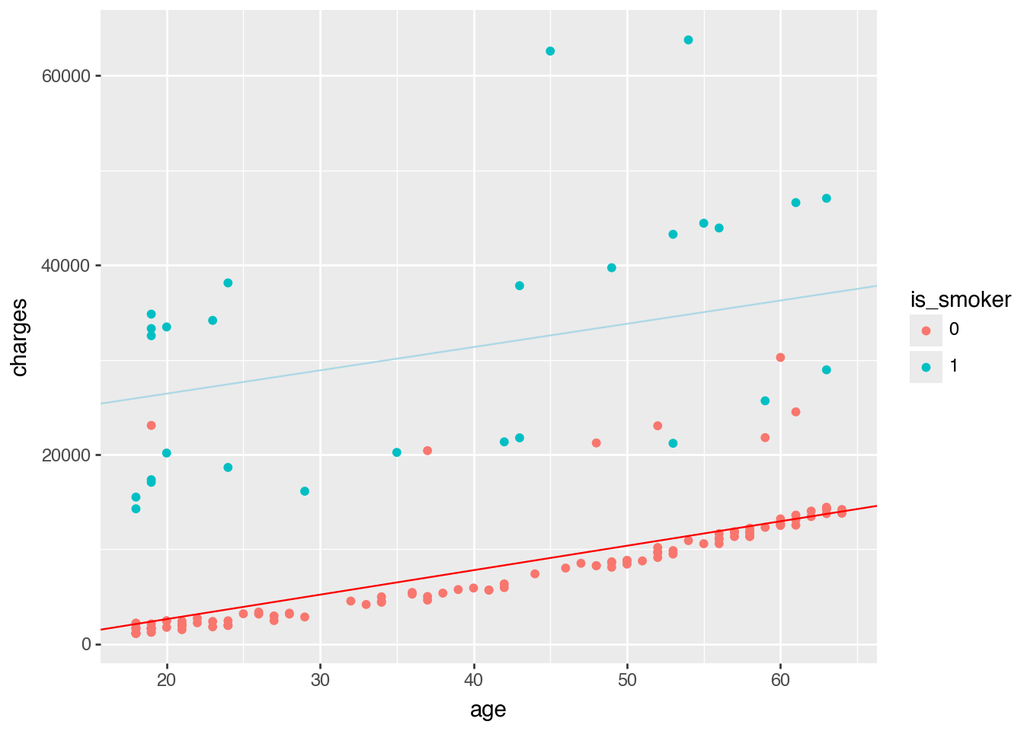

```python
(p9.ggplot(insurance_new,
p9.aes(
  x = "age",
  y = "charges",
  color="is_smoker"
))
+ p9.geom_point()
+ p9.geom_abline(intercept=-2524.685690084003, slope=258.179772, color='red')
+ p9.geom_abline(intercept=21524.181747865998, slope=245.7264773, color='lightblue')
)
```

## Part 5: Full Exploration

```python
insurance["is_smoker"]=insurance["is_smoker"].astype(float)
insurance_new["is_smoker"]=insurance_new["is_smoker"].astype(float)
```

model idea:

```python
insurance["bmisq"]=insurance["bmi"]**2
insurance_new["bmisq"]=insurance_new["bmi"]**2
```

```python
X_explore=insurance[["age", "bmi", "bmisq", "is_smoker", "smoke_bmi", "smoke_age"]]
lr_explore=LinearRegression()
lr_explore.fit(X_explore, y)
```

```
LinearRegression()
```

```python
r2_score(insurance_new['charges'], lr_explore.predict(insurance_new[["age", "bmi", "bmisq", "is_smoker", "smoke_bmi", "smoke_age"]]))
```

```
0.8604288939602411
```

```python
mean_squared_error(insurance_new['charges'], lr_explore.predict(insurance_new[["age", "bmi", "bmisq", "is_smoker", "smoke_bmi", "smoke_age"]]))
```

```
21640476.7819893
```

For the full exploration section, I used the model from part 4 except I added a squared term of bmi. This model has the best R^2 and MSE on the new data, meaning it does not overfit based on the training data.